# DC_Python_E5_Libraries

## Episode 5 - ['Libraries'](https://swcarpentry.github.io/python-novice-gapminder/06-libraries/index.html)

### Learming outcomes

- Explain what software libraries are and why programmers create and use them.
- Write programs that import and use modules from Python’s standard library.
- Find and read documentation for the standard library interactively (in the interpreter) and online.

### Most of the power of a programming language is in its libraries

A library is a collection of files (called *modules*) that contains functions for use by other programs.

- May also contain data values (e.g., numerical constants, like '*pi*') and other things.
- A given library's contents are supposed to be related, but there’s no way to enforce that.

The Python **[standard library](https://docs.python.org/3/library/)** is an extensive suite of modules that comes with Python itself.

Many additional libraries are available from **[PyPI](https://pypi.org) (the Python Package Index)**.

We will see later how to load libraries, for instance.

*NB: The terms 'library' and 'package' and even 'modules' are often used interchangeably

### Before using, we have to *import* libraries

1. Use **import** command to *load a library module* into a program’s memory.
2. Then refer to things from the module as **module_name.thing_name**.

Python uses '**.**' to indicate “*part of*” (*e.g. import a specific module from a particul;ar collection of modules*).

Using **math** module (or *sub-library*), one of the core *modules in the standard library* in the following example.

```python
import math
```

```python
print('pi is', math.pi)
```

```
pi is 3.141592653589793
```

```python
print('cos(pi) is', math.cos(math.pi))
```

```
cos(pi) is -1.0
```

- Have to refer to each item with the module’s name.
  - **math.cos(pi) won’t work**: the reference to *pi* doesn’t somehow “*inherit*” the function’s reference to *math*.

## Use the *help()* to learn about the contents of a library module

Works just like help for a function.

```python
help(math)
```

```
Help on module math:

NAME
    math

MODULE REFERENCE
    https://docs.python.org/3.7/library/math

    The following documentation is automatically generated from the Python
    source files.  It may be incomplete, incorrect or include features that
    are considered implementation detail and may vary between Python
    implementations.  When in doubt, consult the module reference at the
    location listed above.

DESCRIPTION
    This module provides access to the mathematical functions
    defined by the C standard.

FUNCTIONS
    acos(x, /)
        Return the arc cosine (measured in radians) of x.

    acosh(x, /)
        Return the inverse hyperbolic cosine of x.

    asin(x, /)
        Return the arc sine (measured in radians) of x.

    asinh(x, /)
        Return the inverse hyperbolic sine of x.

    atan(x, /)
        Return the arc tangent (measured in radians) of x.

    atan2(y, x, /)
        Return the arc tangent (measured in radians) of y/x.

        Unlike atan(y/x), the signs of both x and y are considered.

    atanh(x, /)
```

[output cut: 159 more lines]

```

    trunc(x, /)
        Truncates the Real x to the nearest Integral toward 0.

        Uses the __trunc__ magic method.

DATA
    e = 2.718281828459045
    inf = inf
    nan = nan
    pi = 3.141592653589793
    tau = 6.283185307179586

FILE
    /opt/anaconda3/lib/python3.7/lib-dynload/math.cpython-37m-darwin.so
```

### Import specific items (*objects or elements*) from a library module to shorten program code

- Use **from ... import ...** to load only specific items from a library module into the program memory.
- Then refer to them directly without library name as *prefix (e.g. 'math.pi')*.

```python
from math import cos, pi
```

```python
print('cos(pi) is', cos(pi))
```

```
cos(pi) is -1.0
```

### When we need the complete library, create an *alias* for a library module when importing it to shorten program code

But can make programs harder to understand, since readers must learn your program’s aliases. Therefore these *naming conventions* in place.

```python
import matplotlib.pyplot as plt # equivalent as: from matplotlib import pyplot as plt
import numpy as np

x = np.arange(0,4*np.pi,0.1)   # start,stop,step
y = np.cos(x)
```

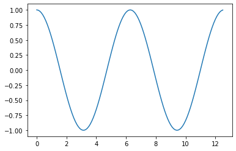

```python
plt.plot(x,y)
plt.show()
```

```python
x2 = ['2016','2017','2018']
y2 = [1252,1632,1692]
```

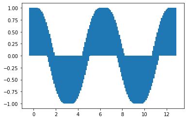

```python
plt.bar(x, y, align='center')
plt.show()
```

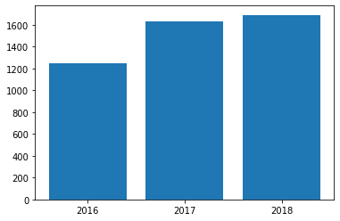

```python
plt.bar(x2, y2, align='center')
plt.show()
```